# Test-Retest Reliability of Core Lexicon Analysis

Authors

Affiliations

Sarah Grace Dalton

University of Georgia, Department of Communication Sciences and Special Education

Robert Cavanaugh

MGH Institute of Health Professions, School of Health and Rehabilitation Sciences

Brielle C. Stark

Indiana University Bloomington, Department of Speech, Language, and Hearing Sciences

### Load packages and setup file reading

```r
library(tidyverse)
library(here)
library(lme4)
library(readxl)
library(boot)
library(flextable)
library(easystats)
library(officer)

source("gtheory-icc.R")
set.seed(42)

raw_data <- read_csv(here::here("data", "corelex-deid-data.csv"))
```

### Data Cleaning

```r
all_data = raw_data |>
  select(-difference) |>
  pivot_longer(cols = starts_with("t"),
               names_to = "time",
               values_to = "score") |>
  rename(stimuli = sheet_name) |>
  mutate(across(where(is.character), as.factor),
         participant = as.factor(paste0("p", str_extract(participant, "^[^.]*")))) |>
  mutate(max = case_when(
    stimuli == "Cat" ~ 35,
    stimuli == "Cinderella" ~ 95,
    stimuli == "Sandwich" ~ 25,
    stimuli == "Umbrella" ~ 36,
    stimuli == "Window" ~ 24,
    TRUE ~ NA
  )) |>
  mutate(percent_acc = score/max)

knitr::kable(head(all_data))
```

| stimuli | participant | dx | time | score | max | percent_acc |
| --- | --- | --- | --- | --- | --- | --- |
| Cat | pP24 | pwa | t1 | 25 | 35 | 0.7142857 |
| Cat | pP24 | pwa | t2 | 30 | 35 | 0.8571429 |
| Cat | pP104 | pwa | t1 | 25 | 35 | 0.7142857 |
| Cat | pP104 | pwa | t2 | 24 | 35 | 0.6857143 |
| Cat | pP92 | pwa | t1 | 0 | 35 | 0.0000000 |
| Cat | pP92 | pwa | t2 | 5 | 35 | 0.1428571 |

### Visualize test-retest

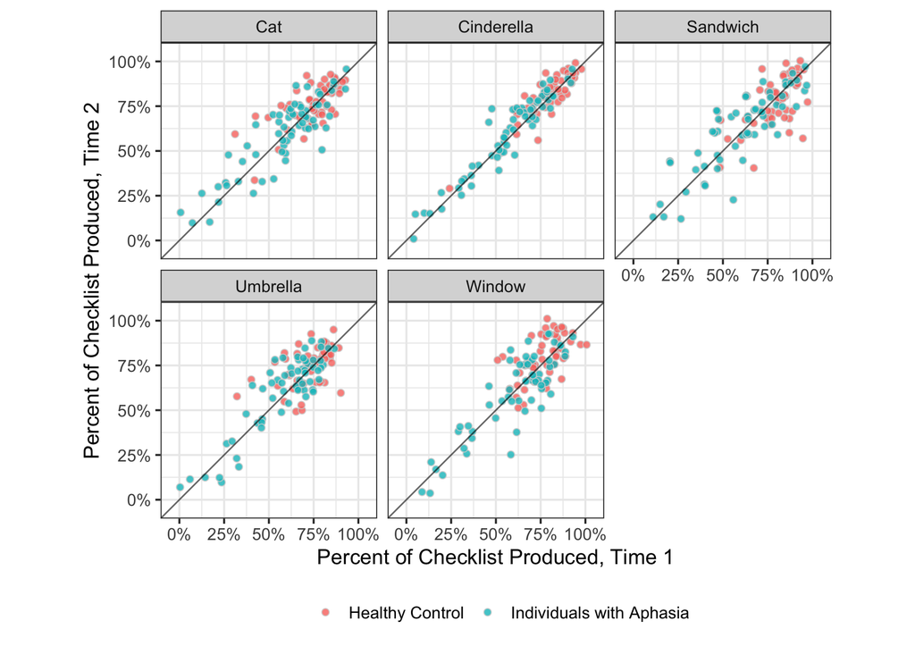

```r
all_wide = all_data |> select(-score) |>
  pivot_wider(names_from = time, values_from = percent_acc)

p1 = all_wide |>
  mutate(dx = ifelse(dx == "control", "Healthy Control", "Individuals with Aphasia")) |>
  ggplot(aes(x = t1, y = t2, fill = dx)) +
  #geom_point() +
  geom_jitter(alpha = 0.8, size = 2, shape = 21, color = "lightgrey", width = .015, height = 0.015) +
  geom_abline(alpha = 0.6) +
  facet_wrap(~stimuli, ncol = 3) +
  scale_y_continuous(limits = c(-0.05, 1.05), labels = scales::label_percent(), breaks = seq(0, 1, 0.25)) +
  scale_x_continuous(limits = c(-0.05, 1.05), labels = scales::label_percent(), breaks = seq(0, 1, 0.25)) +
  theme_bw(base_size = 14) +
  theme(legend.position = "bottom", aspect.ratio = 1) +
  labs(fill = "", x = "Percent of Checklist Produced, Time 1", y = "Percent of Checklist Produced, Time 2") +
  coord_fixed()

ggsave(plot = p1, here::here("output" , "figure 1.png"), height = 7, width = 9)

p1
```

### Estimating reliability under a G-theory framework

- For single rater, dependability coefficient is equivalent to $ICC_{A, 1}$
- For single rater generalizability coefficient is equivalent to $ICC_{C,1}$

Here is an example of how the function works:

- from an `lmer` model, extract the participant variance and the residual variance; the icc is the ratio of participant variance over total variance.
- Calculated for healthy control participants with the Cat stimuli
- Typically, we would include a random efect for time, but since there are only two timepoints, it is not identifiable; and there is no difference between including it and not.

```r
calc_icc <- function(model) {
  vc <- VarCorr(model)
  s_participant <- as.numeric(vc$participant[1])
  s_residual <- sigma(model)^2

  icc <- s_participant / (s_participant + s_residual)
  return(icc)
}

m0 <- lmer(score ~ 1 + (1|participant), data = all_data |> filter(dx == "control", stimuli == "Cat"))
calc_icc(m0)
```

```
[1] 0.6736149
```

Separately, we modified the bootstrap the 95% CI by resampling participants (gtheory-icc.R).

```r
cat_control <- all_data |> filter(dx == "control", stimuli == "Cat")

cat_icc = calc_icc_formula(
  formula = score ~ 1 + (1|participant),
  icc_facet = "participant",
  data = cat_control,
  R = 1000,
  decimal = 2
)

cat_icc$icc_results
```

```
# A tibble: 1 × 5
    icc ci_lower ci_upper ci_95        formula
  <dbl>    <dbl>    <dbl> <chr>        <chr>
1  0.67    0.524    0.771 [0.52, 0.77] σ²participant / (σ²participant + σ²resid…
```

Here, we run it on all combinations of group and stimuli:

```r
# Run ICC analysis on all stimuli / dx
icc_A1 <- all_data |>
  group_nest(stimuli, dx) |>
  mutate(
    icc_results = map(data,
                      ~calc_icc_formula(score ~ 1 + (1|participant),
                      "participant", .x, R = 1000))
  )

# Extract ICC results table
icc_table <- icc_A1 |>
  mutate(icc_data = map(icc_results, "icc_results")) |>
  select(stimuli, dx, icc_data) |>
  unnest(icc_data)

# Extract variance components table
variance_table <- icc_A1 |>
  mutate(var_data = map(icc_results, "variance_components")) |>
  select(stimuli, dx, var_data) |>
  unnest(var_data)

manuscript_table = icc_table |>
  select(Stimuli = stimuli, Group = dx, ICC = icc, `95% CI` = `ci_95`) |>
  flextable() |>
  set_table_properties(align = "left") |>   # Make sure table is left-aligned
  flextable::set_caption(apa_caption("Table X. Reliability Estimtes by Stimuli and Group"), align_with_table = TRUE,
                         word_stylename = "Normal",
                         fp_p = fp_par(text.align = "left")) |>
  flextable::autofit(add_w = 0, add_h = 1) |>
  flextable::add_footer_lines(values = "Note: ICC estimates refer to ICCA,1.") |>
  theme_apa2()

# To save it as a word document:
doc <- officer::read_docx()
# add the table to the document
doc <- body_add_flextable(doc, value = manuscript_table)
# filename within the path we want
print(doc, target = "output/icc_by_stimuli_and_group.docx")


knitr::kable(icc_table)
```

| stimuli | dx | icc | ci_lower | ci_upper | ci_95 | formula |
| --- | --- | --- | --- | --- | --- | --- |
| Cat | control | 0.67 | 0.5283447 | 0.7800370 | [0.53, 0.78] | σ²participant / (σ²participant + σ²residual) |
| Cat | pwa | 0.87 | 0.8177387 | 0.9162392 | [0.82, 0.92] | σ²participant / (σ²participant + σ²residual) |
| Cinderella | control | 0.87 | 0.7096033 | 0.9298273 | [0.71, 0.93] | σ²participant / (σ²participant + σ²residual) |
| Cinderella | pwa | 0.95 | 0.9225698 | 0.9741342 | [0.92, 0.97] | σ²participant / (σ²participant + σ²residual) |
| Sandwich | control | 0.57 | 0.3591005 | 0.7384804 | [0.36, 0.74] | σ²participant / (σ²participant + σ²residual) |
| Sandwich | pwa | 0.86 | 0.7919299 | 0.9060560 | [0.79, 0.91] | σ²participant / (σ²participant + σ²residual) |
| Umbrella | control | 0.48 | 0.3313196 | 0.6234873 | [0.33, 0.62] | σ²participant / (σ²participant + σ²residual) |
| Umbrella | pwa | 0.89 | 0.8192951 | 0.9267247 | [0.82, 0.93] | σ²participant / (σ²participant + σ²residual) |
| Window | control | 0.53 | 0.3861238 | 0.6516181 | [0.39, 0.65] | σ²participant / (σ²participant + σ²residual) |
| Window | pwa | 0.86 | 0.7814661 | 0.9139330 | [0.78, 0.91] | σ²participant / (σ²participant + σ²residual) |

### Check that the results are basically the same as classical test theory:

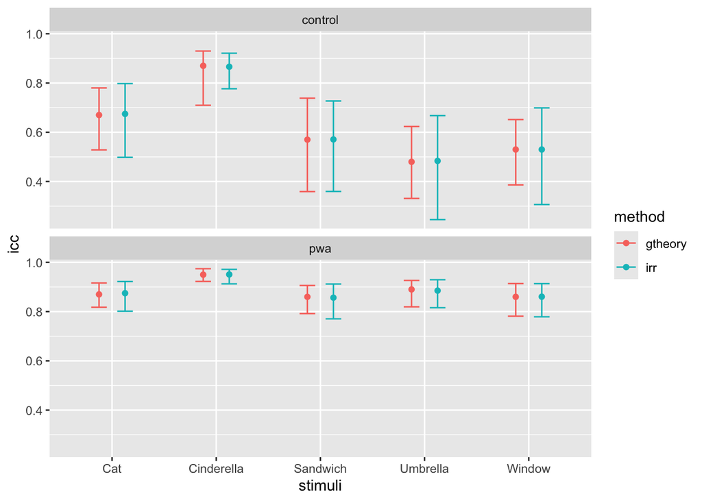

```r
icc_results <- all_data |>
  group_by(stimuli, dx) |>
  summarise(
    n = n_distinct(participant),
    icc_data = list({
      wide_data <- cur_data() |>
        select(participant, time, score) |>
        pivot_wider(names_from = time, values_from = score) |>
        select(-participant)

      icc_result <- irr::icc(wide_data, model = "two", type = "agreement", unit = "single")

      tibble(
        icc = icc_result$value,
        lower_ci = icc_result$lbound,
        upper_ci = icc_result$ubound
      )
    })
  ) |>
  unnest(icc_data)
a = icc_A1 |>
  mutate(icc_data = map(icc_results, "icc_results")) |>
  select(stimuli, dx, icc_data) |>
  unnest(icc_data)|>
  select(stimuli, dx, icc, ci_lower, ci_upper) |> mutate(method = "gtheory", icc = icc)
b = icc_results |> select(stimuli, dx, icc, ci_lower = lower_ci, ci_upper = upper_ci) |> mutate(method = "irr")
bind_rows(a, b) |>
  ggplot(aes(x = stimuli, color = method, y = icc)) +
  geom_errorbar(aes(ymin = ci_lower, ymax = ci_upper),
                position = position_dodge(width = 0.5),
                width = 0.3) +
  geom_point(position = position_dodge(width = 0.5)) +
  facet_wrap(~dx, ncol = 1)
```

They are very similar. Minor differences in the confidence intervals do not impact conclusions.

### Consistency ICCs

Generalizability coefficients or Consistency ICCs for situations where absolute agreement is not necessary, as recommended by tenHove 2024.

```r
# Run ICC analysis on all stimuli / dx
icc_C1 <- all_data |>
  group_nest(stimuli, dx) |>
  mutate(
    icc_results = map(data, ~calc_icc_formula(score ~ 1 + time + (1|participant), "participant", .x, R = 1000))
  )
```

```
Model fit warnings detected, inspect $warnings for more information
```

```r
# Extract ICC results table
icc_table_c <- icc_C1 |>
  mutate(icc_data = map(icc_results, "icc_results")) |>
  select(stimuli, dx, icc_data) |>
  unnest(icc_data)

# Extract variance components table
variance_table_c <- icc_C1 |>
  mutate(var_data = map(icc_results, "variance_components")) |>
  select(stimuli, dx, var_data) |>
  unnest(var_data)

manuscript_table2 = icc_table_c |>
    select(Stimuli = stimuli, Group = dx, ICC = icc, `95% CI` = `ci_95`) |>
  flextable() |>
  set_table_properties(align = "left") |>   # Make sure table is left-aligned
  flextable::set_caption(apa_caption("Table X. Reliability Estimtes by Stimuli and Group"), align_with_table = TRUE,
                         word_stylename = "Normal",
                         fp_p = fp_par(text.align = "left")) |>
  flextable::autofit(add_w = 0, add_h = 1) |>
  flextable::add_footer_lines(values = "Note: ICC estimates refer to ICC C,1.") |>
  theme_apa2()

# To save it as a word document:
doc <- officer::read_docx()
# add the table to the document
doc <- body_add_flextable(doc, value = manuscript_table2)
# filename within the path we want
print(doc, target = "output/icc_by_stimuli_and_group_consistency.docx")


knitr::kable(icc_table_c |> select(-ci_lower, -ci_upper))
```

| stimuli | dx | icc | ci_95 | formula |
| --- | --- | --- | --- | --- |
| Cat | control | 0.68 | [0.53, 0.77] | σ²participant / (σ²participant + σ²residual) |
| Cat | pwa | 0.87 | [0.81, 0.92] | σ²participant / (σ²participant + σ²residual) |
| Cinderella | control | 0.87 | [0.72, 0.93] | σ²participant / (σ²participant + σ²residual) |
| Cinderella | pwa | 0.96 | [0.93, 0.98] | σ²participant / (σ²participant + σ²residual) |
| Sandwich | control | 0.57 | [0.33, 0.74] | σ²participant / (σ²participant + σ²residual) |
| Sandwich | pwa | 0.86 | [0.79, 0.91] | σ²participant / (σ²participant + σ²residual) |
| Umbrella | control | 0.49 | [0.33, 0.62] | σ²participant / (σ²participant + σ²residual) |
| Umbrella | pwa | 0.89 | [0.83, 0.93] | σ²participant / (σ²participant + σ²residual) |
| Window | control | 0.54 | [0.41, 0.67] | σ²participant / (σ²participant + σ²residual) |
| Window | pwa | 0.86 | [0.8, 0.91] | σ²participant / (σ²participant + σ²residual) |

```r
icc_all = icc_table |>
  select(stimuli, dx, icc_a1 = icc, ci_95_a1 = ci_95) |>
  left_join(
    icc_table_c |> select(stimuli, dx, icc_c1 = icc, ci_95_c1 = ci_95),
    by = join_by(stimuli, dx)
  )

manuscript_table4 = icc_all |>
  rename(Stimuli = stimuli, Group = dx) |>
  flextable() |>
  set_table_properties(align = "left") |>
  compose(
    j = "icc_a1",
    part = "header",
    value = as_paragraph("ICC", as_sub("A,1"))
  ) |>
  compose(
    j = "ci_95_a1",
    part = "header",
    value = as_paragraph("95% CI", as_sub("A,1"))
  ) |>
  compose(
    j = "icc_c1",
    part = "header",
    value = as_paragraph("ICC", as_sub("C,1"))
  ) |>
  compose(
    j = "ci_95_c1",
    part = "header",
    value = as_paragraph("95% CI", as_sub("C,1"))
  ) |>
  flextable::set_caption(apa_caption("Table 3. Estimates of absolute and relative reliability by stimulus for individuals with aphasia and healthy controls"),
                         align_with_table = TRUE,
                         word_stylename = "Normal",
                         fp_p = fp_par(text.align = "left")) |>
  flextable::autofit(add_w = 0, add_h = 1) |>
    flextable::add_footer_lines(values = "Note: ICCA,1 represents single-rater agreement intraclass correlation coefficients (dependability coefficients) and ICCC,1 refers to single-rater consistency intraclass correlation coefficients (generalizability coefficients). ") |>
  theme_apa2()

# To save it as a word document:
doc <- officer::read_docx()
# add the table to the document
doc <- body_add_flextable(doc, value = manuscript_table4)
# filename within the path we want
print(doc, target = "output/icc_by_stimuli_and_group_all.docx")
```

We can also get estimates of “time” to examine practice effects directly:

```r
time_table = icc_C1 |>
   mutate(
       fixed_effects = map(icc_results, ~ {
           .x$paramters |>
               filter(Effects == "fixed", Parameter != "(Intercept)")
       })
   ) |>
   select(stimuli, dx, fixed_effects) |>
   unnest(fixed_effects) |> format_table()

time_table_manuscript = time_table |>
  select(-Effects, -df, -t, -Group) |>
  rename(Group = dx) |>
  flextable() |>
  set_table_properties(align = "left") |>   # Make sure table is left-aligned
  flextable::set_caption(apa_caption("Supplemental Table 1. Fixed effects of time for all stimuli and groups"), align_with_table = TRUE,
                         word_stylename = "Normal",
                         fp_p = fp_par(text.align = "left")) |>
  flextable::autofit(add_w = 0, add_h = 1) |>
  flextable::add_footer_lines(values = "") |>
  theme_apa2()

# To save it as a word document:
doc <- officer::read_docx()
# add the table to the document
doc <- body_add_flextable(doc, value = time_table_manuscript)
# filename within the path we want
print(doc, target = "output/supplement-time-1.docx")

time_table
```

```
      stimuli      dx Parameter Coefficient   SE        95% CI     t  df     p
1         Cat control    timet2        0.68 0.48 [-0.26, 1.62]  1.43 102 0.156
2         Cat     pwa    timet2        0.40 0.46 [-0.52, 1.32]  0.85 122 0.395
3  Cinderella control    timet2        1.44 0.82 [-0.18, 3.06]  1.77 100 0.081
4  Cinderella     pwa    timet2        2.25 0.80 [ 0.66, 3.83]  2.80 118 0.006
5    Sandwich control    timet2       -0.47 0.41 [-1.28, 0.34] -1.16 102 0.250
6    Sandwich     pwa    timet2        0.34 0.38 [-0.41, 1.09]  0.89 114 0.374
7    Umbrella control    timet2        0.71 0.58 [-0.45, 1.86]  1.22  98 0.227
8    Umbrella     pwa    timet2        0.77 0.44 [-0.10, 1.65]  1.75 120 0.083
9      Window control    timet2        0.65 0.36 [-0.07, 1.38]  1.80 100 0.076
10     Window     pwa    timet2       -0.21 0.35 [-0.90, 0.48] -0.60 120 0.549
   Effects Group
1    fixed
2    fixed
3    fixed
4    fixed
5    fixed
6    fixed
7    fixed
8    fixed
9    fixed
10   fixed
```

### Overall effects including all stimuli

Looking at reliability as if stimuli were facets. This includes estimates with and without group as a fixed effect

```r
# first we have to standardize the scores. I've done this by calculating %
# accuracy using the max possible scores. this normalizes the scores accounting
# for stimuli length.

icc_5 = calc_icc_formula(
  formula = percent_acc ~ 1 + (1|participant) + (1|stimuli) + (1|stimuli:participant),
  icc_facet = "participant",
  data = all_data,
  R = 1000
)
```

```
Model fit warnings detected, inspect $warnings for more information
```

```r
icc_5_dx = calc_icc_formula(
  formula = percent_acc ~ 1 + dx + (1|participant) + (1|stimuli)+ (1|stimuli:participant),
  icc_facet = "participant",
  data = all_data,
  R = 1000
)
```

```
Model fit warnings detected, inspect $warnings for more information
```

```r
knitr::kable(bind_rows(icc_5$icc_results |> mutate(method = "collapsed") |> select(-ci_upper, -ci_lower),
                       icc_5_dx$icc_results |> mutate(method = "dx-removed") |> select(-ci_upper, -ci_lower)
                       ))
```

| icc | ci_95 | formula | method |
| --- | --- | --- | --- |
| 0.77 | [0.7, 0.82] | σ²participant / (σ²participant + σ²stimuli + σ²stimuli:participant + σ²residual) | collapsed |
| 0.71 | [0.63, 0.77] | σ²participant / (σ²participant + σ²stimuli + σ²stimuli:participant + σ²residual) | dx-removed |

```r
pwa = all_data |> filter(dx == "pwa")

icc_5_pwa = calc_icc_formula(
  formula = percent_acc ~ 1 + (1|participant) + (1|stimuli) + (1|stimuli:participant),
  icc_facet = "participant",
  data = pwa,
  R = 1000
)
```

```
Model fit warnings detected, inspect $warnings for more information
```

```r
icc_5_pwa
```

```
$icc_results
# A tibble: 1 × 5
    icc ci_lower ci_upper ci_95        formula
  <dbl>    <dbl>    <dbl> <chr>        <chr>
1  0.81    0.743    0.854 [0.74, 0.85] σ²participant / (σ²participant + σ²stimu…

$variance_components
# A tibble: 4 × 3
  component           variance percentage
  <chr>                  <dbl> <chr>
1 participant             0.04 81.46%
2 stimuli                 0    0.23%
3 stimuli:participant     0    7.35%
4 residual                0.01 10.96%

$warnings
# A tibble: 3 × 2
  warning                                                                  count
  <chr>                                                                    <int>
1 Singular fit detected                                                      172
2 unable to evaluate scaled gradient                                           2
3 Model failed to converge: degenerate  Hessian with 1 negative eigenvalu…     2

$paramters
# Fixed Effects

Parameter   | Coefficient |   SE |       95% CI | t(609) |      p
-----------------------------------------------------------------
(Intercept) |        0.59 | 0.03 | [0.54, 0.64] |  23.09 | < .001

# Random Effects

Parameter                           | Coefficient
-------------------------------------------------
SD (Intercept: stimuli:participant) |        0.06
SD (Intercept: participant)         |        0.20
SD (Intercept: stimuli)             |        0.01
SD (Residual)                       |        0.07
```

```
Uncertainty intervals (equal-tailed) and p-values (two-tailed) computed
  using a Wald t-distribution approximation. Uncertainty intervals for
  random effect variances computed using a Wald z-distribution
  approximation.
```

```r
control = all_data |> filter(dx == "control")

icc_5_control = calc_icc_formula(
  formula = percent_acc ~ 1 + (1|participant) + (1|stimuli) + (1|stimuli:participant),
  icc_facet = "participant",
  data = control,
  R = 1000
)

icc_5_control
```

```
$icc_results
# A tibble: 1 × 5
    icc ci_lower ci_upper ci_95        formula
  <dbl>    <dbl>    <dbl> <chr>        <chr>
1  0.35    0.226    0.436 [0.23, 0.44] σ²participant / (σ²participant + σ²stimu…

$variance_components
# A tibble: 4 × 3
  component           variance percentage
  <chr>                  <dbl> <chr>
1 participant             0.01 35.17%
2 stimuli                 0    3.94%
3 stimuli:participant     0    25.19%
4 residual                0.01 35.70%

$warnings
# A tibble: 0 × 2
# ℹ 2 variables: warning <chr>, count <int>

$paramters
# Fixed Effects

Parameter   | Coefficient |   SE |       95% CI | t(517) |      p
-----------------------------------------------------------------
(Intercept) |        0.77 | 0.02 | [0.74, 0.80] |  49.46 | < .001

# Random Effects

Parameter                           | Coefficient
-------------------------------------------------
SD (Intercept: stimuli:participant) |        0.06
SD (Intercept: participant)         |        0.07
SD (Intercept: stimuli)             |        0.02
SD (Residual)                       |        0.07
```

```
Uncertainty intervals (equal-tailed) and p-values (two-tailed) computed
  using a Wald t-distribution approximation. Uncertainty intervals for
  random effect variances computed using a Wald z-distribution
  approximation.
```

### Decision study

- what would be the effects of averaging 1…5 stimuli on reliability?

```r
m_pwa = lmer(percent_acc ~ 1 + (1|participant) + (1|stimuli) + (1|stimuli:participant), data = pwa)
m_control = lmer(percent_acc ~ 1 + (1|participant) + (1|stimuli) + (1|stimuli:participant), data = control)
# Usage:
decision_pwa <- calc_decision_study(m_pwa)  # whatever your model object is called
decision_pwa
```

```
# A tibble: 5 × 6
  n_stimuli g_coefficient ci_lower ci_upper ci_95        convergence_rate
      <int>         <dbl>    <dbl>    <dbl> <chr>                   <dbl>
1         1          0.88     0.87     0.93 [0.87, 0.93]                1
2         2          0.94     0.93     0.97 [0.93, 0.97]                1
3         3          0.96     0.95     0.98 [0.95, 0.98]                1
4         4          0.97     0.96     0.98 [0.96, 0.98]                1
5         5          0.97     0.97     0.99 [0.97, 0.99]                1
```

```r
decision_control <- calc_decision_study(m_control)
decision_control
```

```
# A tibble: 5 × 6
  n_stimuli g_coefficient ci_lower ci_upper ci_95        convergence_rate
      <int>         <dbl>    <dbl>    <dbl> <chr>                   <dbl>
1         1          0.47     0.38     0.65 [0.38, 0.65]                1
2         2          0.64     0.55     0.79 [0.55, 0.79]                1
3         3          0.73     0.65     0.85 [0.65, 0.85]                1
4         4          0.78     0.71     0.88 [0.71, 0.88]                1
5         5          0.82     0.76     0.9  [0.76, 0.9]                 1
```

```r
ds = bind_rows(decision_pwa |> mutate(group = "pwa"), decision_control |> mutate(group = "control"))
ds
```

```
# A tibble: 10 × 7
   n_stimuli g_coefficient ci_lower ci_upper ci_95        convergence_rate group
       <int>         <dbl>    <dbl>    <dbl> <chr>                   <dbl> <chr>
 1         1          0.88     0.87     0.93 [0.87, 0.93]                1 pwa
 2         2          0.94     0.93     0.97 [0.93, 0.97]                1 pwa
 3         3          0.96     0.95     0.98 [0.95, 0.98]                1 pwa
 4         4          0.97     0.96     0.98 [0.96, 0.98]                1 pwa
 5         5          0.97     0.97     0.99 [0.97, 0.99]                1 pwa
 6         1          0.47     0.38     0.65 [0.38, 0.65]                1 cont…
 7         2          0.64     0.55     0.79 [0.55, 0.79]                1 cont…
 8         3          0.73     0.65     0.85 [0.65, 0.85]                1 cont…
 9         4          0.78     0.71     0.88 [0.71, 0.88]                1 cont…
10         5          0.82     0.76     0.9  [0.76, 0.9]                 1 cont…
```

```r
ds_plot = ds |>
  ggplot(aes(x = n_stimuli, y = g_coefficient, color = group)) +
  geom_point( position = position_dodge(0.3)) +
  geom_errorbar(aes(ymin=ci_lower, ymax = ci_upper), width = 0.3, position = position_dodge(0.3)) +
  theme_bw(base_size = 12) +
  scale_y_continuous(labels = scales::label_percent(), breaks = seq(0, 1, 0.1), limits = c(0,1)) +
  theme(legend.position = "bottom") +
  labs(y = "Estimate of Reliability", x = "Number of Stimuli")

ggsave(plot = ds_plot, filename = here::here("output", "decision-study.png"))
```

### MDC

Calculating MDC for each stimuli. MDC 95

```r
# Run ICC analysis on all stimuli / dx
mdc <- all_data |>
  group_nest(stimuli, dx) |>
  mutate(
    mdc_results = map(data, ~calc_mdc_formula(score ~ 1 + (1|participant), icc_facet = "participant", .x))
  )

# Extract ICC results table
mdc_all <- mdc |>
  mutate(mdc_data = map(mdc_results, "mdc_results")) |>
  select(stimuli, dx, mdc_data) |>
  unnest(mdc_data) |>
  left_join(all_data |>  distinct(stimuli, dx, max),
                     by = c("stimuli", "dx")) |>
            mutate(percent_of_total = scales::label_percent(0.01)(mdc/max))

manuscript_table3 = mdc_all |>
  select(Stimuli = stimuli, Group = dx, MDC = mdc, SEM = sem, `% of Total` = percent_of_total) |>
  flextable() |>
  set_table_properties(align = "left") |>   # Make sure table is left-aligned
  flextable::set_caption(apa_caption("Table 4. Minimum Detectable Change Scores by stimulus for individuals with aphasia and healthy controls"), align_with_table = TRUE,
                         word_stylename = "Normal",
                         fp_p = fp_par(text.align = "left")) |>
  flextable::autofit(add_w = 0, add_h = 1) |>
  flextable::add_footer_lines(values = "Note: MDC: Minimum Detectible Change, SEM = Standard Error of the Mean") |>
  theme_apa2()

# To save it as a word document:
doc <- officer::read_docx()
# add the table to the document
doc <- body_add_flextable(doc, value = manuscript_table3)
# filename within the path we want
print(doc, target = "output/imdc_table.docx")


knitr::kable(mdc_all)
```

| stimuli | dx | mdc | sem | error_variance | error_type | max | percent_of_total |
| --- | --- | --- | --- | --- | --- | --- | --- |
| Cat | control | 6.85 | 2.47 | 6.11 | residual | 35 | 19.57% |
| Cat | pwa | 7.21 | 2.60 | 6.77 | residual | 35 | 20.60% |
| Cinderella | control | 11.78 | 4.25 | 18.07 | residual | 95 | 12.40% |
| Cinderella | pwa | 12.95 | 4.67 | 21.83 | residual | 95 | 13.63% |
| Sandwich | control | 5.83 | 2.10 | 4.42 | residual | 25 | 23.32% |
| Sandwich | pwa | 5.71 | 2.06 | 4.24 | residual | 25 | 22.84% |
| Umbrella | control | 8.16 | 2.94 | 8.67 | residual | 36 | 22.67% |
| Umbrella | pwa | 6.94 | 2.50 | 6.27 | residual | 36 | 19.28% |
| Window | control | 5.26 | 1.90 | 3.60 | residual | 24 | 21.92% |
| Window | pwa | 5.36 | 1.93 | 3.73 | residual | 24 | 22.33% |